# Part I - Prosper Loan Dataset

# by Iyanujesu Akinyefa

## Introduction

> This data set contains 113,937 loans with 81 variables on each loan, including loan amount, borrower rate (or interest rate), current loan status, borrower income, and many others

## Preliminary Wrangling

```python
# import all packages and set plots to be embedded inline
import numpy as np
import pandas as pd
import matplotlib.pyplot as plt
import seaborn as sb

%matplotlib inline
import warnings
warnings.filterwarnings('ignore')
```

> Load in your dataset and describe its properties through the questions below. Try and motivate your exploration goals through this section.

```python
loan_data = pd.read_csv('prosperLoanData.csv')
```

```python
loan_data.head(5)
```

|  | ListingKey | ListingNumber | ListingCreationDate | CreditGrade | Term | LoanStatus | ClosedDate | BorrowerAPR | BorrowerRate | LenderYield | ... | LP_ServiceFees | LP_CollectionFees | LP_GrossPrincipalLoss | LP_NetPrincipalLoss | LP_NonPrincipalRecoverypayments | PercentFunded | Recommendations | InvestmentFromFriendsCount | InvestmentFromFriendsAmount | Investors |
| --- | --- | --- | --- | --- | --- | --- | --- | --- | --- | --- | --- | --- | --- | --- | --- | --- | --- | --- | --- | --- | --- |
| 0 | 1021339766868145413AB3B | 193129 | 2007-08-26 19:09:29.263000000 | C | 36 | Completed | 2009-08-14 00:00:00 | 0.16516 | 0.1580 | 0.1380 | ... | -133.18 | 0.0 | 0.0 | 0.0 | 0.0 | 1.0 | 0 | 0 | 0.0 | 258 |
| 1 | 10273602499503308B223C1 | 1209647 | 2014-02-27 08:28:07.900000000 | NaN | 36 | Current | NaN | 0.12016 | 0.0920 | 0.0820 | ... | 0.00 | 0.0 | 0.0 | 0.0 | 0.0 | 1.0 | 0 | 0 | 0.0 | 1 |
| 2 | 0EE9337825851032864889A | 81716 | 2007-01-05 15:00:47.090000000 | HR | 36 | Completed | 2009-12-17 00:00:00 | 0.28269 | 0.2750 | 0.2400 | ... | -24.20 | 0.0 | 0.0 | 0.0 | 0.0 | 1.0 | 0 | 0 | 0.0 | 41 |
| 3 | 0EF5356002482715299901A | 658116 | 2012-10-22 11:02:35.010000000 | NaN | 36 | Current | NaN | 0.12528 | 0.0974 | 0.0874 | ... | -108.01 | 0.0 | 0.0 | 0.0 | 0.0 | 1.0 | 0 | 0 | 0.0 | 158 |
| 4 | 0F023589499656230C5E3E2 | 909464 | 2013-09-14 18:38:39.097000000 | NaN | 36 | Current | NaN | 0.24614 | 0.2085 | 0.1985 | ... | -60.27 | 0.0 | 0.0 | 0.0 | 0.0 | 1.0 | 0 | 0 | 0.0 | 20 |

5 rows × 81 columns

```python
loan_data.shape
```

```
(113937, 81)
```

```python
loan_data.info()
```

```
<class 'pandas.core.frame.DataFrame'>
RangeIndex: 113937 entries, 0 to 113936
Data columns (total 81 columns):
 #   Column                               Non-Null Count   Dtype
---  ------                               --------------   -----
 0   ListingKey                           113937 non-null  object
 1   ListingNumber                        113937 non-null  int64
 2   ListingCreationDate                  113937 non-null  object
 3   CreditGrade                          28953 non-null   object
 4   Term                                 113937 non-null  int64
 5   LoanStatus                           113937 non-null  object
 6   ClosedDate                           55089 non-null   object
 7   BorrowerAPR                          113912 non-null  float64
 8   BorrowerRate                         113937 non-null  float64
 9   LenderYield                          113937 non-null  float64
```

[output cut: 73 more lines]

```python
loan_data.describe()
```

|  | ListingNumber | Term | BorrowerAPR | BorrowerRate | LenderYield | EstimatedEffectiveYield | EstimatedLoss | EstimatedReturn | ProsperRating (numeric) | ProsperScore | ... | LP_ServiceFees | LP_CollectionFees | LP_GrossPrincipalLoss | LP_NetPrincipalLoss | LP_NonPrincipalRecoverypayments | PercentFunded | Recommendations | InvestmentFromFriendsCount | InvestmentFromFriendsAmount | Investors |
| --- | --- | --- | --- | --- | --- | --- | --- | --- | --- | --- | --- | --- | --- | --- | --- | --- | --- | --- | --- | --- | --- |
| count | 1.139370e+05 | 113937.000000 | 113912.000000 | 113937.000000 | 113937.000000 | 84853.000000 | 84853.000000 | 84853.000000 | 84853.000000 | 84853.000000 | ... | 113937.000000 | 113937.000000 | 113937.000000 | 113937.000000 | 113937.000000 | 113937.000000 | 113937.000000 | 113937.000000 | 113937.000000 | 113937.000000 |
| mean | 6.278857e+05 | 40.830248 | 0.218828 | 0.192764 | 0.182701 | 0.168661 | 0.080306 | 0.096068 | 4.072243 | 5.950067 | ... | -54.725641 | -14.242698 | 700.446342 | 681.420499 | 25.142686 | 0.998584 | 0.048027 | 0.023460 | 16.550751 | 80.475228 |
| std | 3.280762e+05 | 10.436212 | 0.080364 | 0.074818 | 0.074516 | 0.068467 | 0.046764 | 0.030403 | 1.673227 | 2.376501 | ... | 60.675425 | 109.232758 | 2388.513831 | 2357.167068 | 275.657937 | 0.017919 | 0.332353 | 0.232412 | 294.545422 | 103.239020 |
| min | 4.000000e+00 | 12.000000 | 0.006530 | 0.000000 | -0.010000 | -0.182700 | 0.004900 | -0.182700 | 1.000000 | 1.000000 | ... | -664.870000 | -9274.750000 | -94.200000 | -954.550000 | 0.000000 | 0.700000 | 0.000000 | 0.000000 | 0.000000 | 1.000000 |
| 25% | 4.009190e+05 | 36.000000 | 0.156290 | 0.134000 | 0.124200 | 0.115670 | 0.042400 | 0.074080 | 3.000000 | 4.000000 | ... | -73.180000 | 0.000000 | 0.000000 | 0.000000 | 0.000000 | 1.000000 | 0.000000 | 0.000000 | 0.000000 | 2.000000 |
| 50% | 6.005540e+05 | 36.000000 | 0.209760 | 0.184000 | 0.173000 | 0.161500 | 0.072400 | 0.091700 | 4.000000 | 6.000000 | ... | -34.440000 | 0.000000 | 0.000000 | 0.000000 | 0.000000 | 1.000000 | 0.000000 | 0.000000 | 0.000000 | 44.000000 |
| 75% | 8.926340e+05 | 36.000000 | 0.283810 | 0.250000 | 0.240000 | 0.224300 | 0.112000 | 0.116600 | 5.000000 | 8.000000 | ... | -13.920000 | 0.000000 | 0.000000 | 0.000000 | 0.000000 | 1.000000 | 0.000000 | 0.000000 | 0.000000 | 115.000000 |
| max | 1.255725e+06 | 60.000000 | 0.512290 | 0.497500 | 0.492500 | 0.319900 | 0.366000 | 0.283700 | 7.000000 | 11.000000 | ... | 32.060000 | 0.000000 | 25000.000000 | 25000.000000 | 21117.900000 | 1.012500 | 39.000000 | 33.000000 | 25000.000000 | 1189.000000 |

8 rows × 61 columns

```python
#subset the Dataframe
cols = ['LoanOriginalAmount', 'ProsperScore', 'BorrowerAPR', 'LoanStatus', 'EmploymentStatus', 'BorrowerRate', 'BorrowerState','Occupation', 'IncomeRange', 'Term', 'ProsperRating (Alpha)',
       'IncomeVerifiable', 'StatedMonthlyIncome', 'MonthlyLoanPayment']
loan_sub = loan_data[cols]
```

```python
loan_sub.head()
```

|  | LoanOriginalAmount | ProsperScore | BorrowerAPR | LoanStatus | EmploymentStatus | BorrowerRate | BorrowerState | Occupation | IncomeRange | Term | ProsperRating (Alpha) | IncomeVerifiable | StatedMonthlyIncome | MonthlyLoanPayment |
| --- | --- | --- | --- | --- | --- | --- | --- | --- | --- | --- | --- | --- | --- | --- |
| 0 | 9425 | NaN | 0.16516 | Completed | Self-employed | 0.1580 | CO | Other | $25,000-49,999 | 36 | NaN | True | 3083.333333 | 330.43 |
| 1 | 10000 | 7.0 | 0.12016 | Current | Employed | 0.0920 | CO | Professional | $50,000-74,999 | 36 | A | True | 6125.000000 | 318.93 |
| 2 | 3001 | NaN | 0.28269 | Completed | Not available | 0.2750 | GA | Other | Not displayed | 36 | NaN | True | 2083.333333 | 123.32 |
| 3 | 10000 | 9.0 | 0.12528 | Current | Employed | 0.0974 | GA | Skilled Labor | $25,000-49,999 | 36 | A | True | 2875.000000 | 321.45 |
| 4 | 15000 | 4.0 | 0.24614 | Current | Employed | 0.2085 | MN | Executive | $100,000+ | 36 | D | True | 9583.333333 | 563.97 |

```python
loan_sub.describe()
```

|  | LoanOriginalAmount | ProsperScore | BorrowerAPR | BorrowerRate | Term | StatedMonthlyIncome | MonthlyLoanPayment |
| --- | --- | --- | --- | --- | --- | --- | --- |
| count | 113937.00000 | 84853.000000 | 113912.000000 | 113937.000000 | 113937.000000 | 1.139370e+05 | 113937.000000 |
| mean | 8337.01385 | 5.950067 | 0.218828 | 0.192764 | 40.830248 | 5.608026e+03 | 272.475783 |
| std | 6245.80058 | 2.376501 | 0.080364 | 0.074818 | 10.436212 | 7.478497e+03 | 192.697812 |
| min | 1000.00000 | 1.000000 | 0.006530 | 0.000000 | 12.000000 | 0.000000e+00 | 0.000000 |
| 25% | 4000.00000 | 4.000000 | 0.156290 | 0.134000 | 36.000000 | 3.200333e+03 | 131.620000 |
| 50% | 6500.00000 | 6.000000 | 0.209760 | 0.184000 | 36.000000 | 4.666667e+03 | 217.740000 |
| 75% | 12000.00000 | 8.000000 | 0.283810 | 0.250000 | 36.000000 | 6.825000e+03 | 371.580000 |
| max | 35000.00000 | 11.000000 | 0.512290 | 0.497500 | 60.000000 | 1.750003e+06 | 2251.510000 |

### What is the structure of your dataset?

The dataset features can be split into two main categories:

> 1. Borrower information
> 2. Loan performance information

### What is/are the main feature(s) of interest in your dataset?

1. What affect the borrower’s APR and interest rate?
2. Are there differences between loans depending on how large the original loan amount was?
3. What factors affect a loan outcome staus?

### What features in the dataset do you think will help support your investigation into your feature(s) of interest?

1. ProsperScore
2. BorrowerAPR
3. EmploymentStatus
4. Occupation
5. IncomeRange
6. LoanStatus
7. loanOriginal amount
8. BorrowerRate
9. Borrowerstate

## Univariate Exploration

```python
# creating a function for chart name, x and y labels, to avoid repetition
def labels(a,b,c):
    """
    This function gives chart title, x and y axis
    --------
    It aims to avoid repetition by taking in three parameters for the chart title and both the x and y axis labels
    """
    return plt.title(a),plt.ylabel(b),plt.xlabel(c)
```

I'll start by looking at the distribution of the main variable of interest: BorrowerAPR

### What is the distribution of the BorrowerAPR and BorrowerRate?

#### Borrowers APR

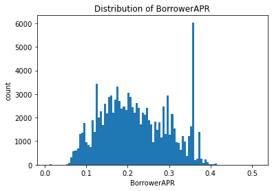

```python
plt.hist(data= loan_sub, x= 'BorrowerAPR', bins = 100)
labels('Distribution of BorrowerAPR', 'count', 'BorrowerAPR');
```

#### BorrowerRate

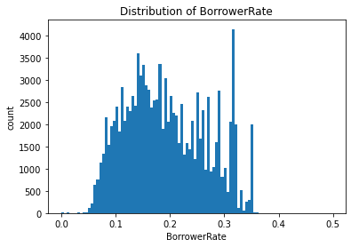

```python
plt.hist(data= loan_sub, x= 'BorrowerRate', bins = 100)
labels('Distribution of BorrowerRate', 'count', 'BorrowerRate');
```

Observations

### What is the distribution of the orignal loan amount collected by borrowers?

#### LoanOriginalAmount

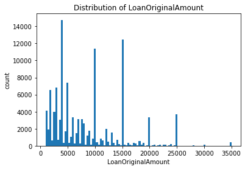

```python
plt.hist(data= loan_sub, x= 'LoanOriginalAmount', bins= 100)
labels('Distribution of LoanOriginalAmount', 'count', 'LoanOriginalAmount');
```

The distribution is right skewed, so let's put it on a log scale to try to normalized the data

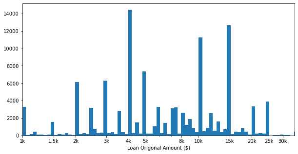

```python
bins_size = 10 ** np.arange(0, np.log10(loan_sub['LoanOriginalAmount'].max())+0.020, 0.020)
plt.figure(figsize=(10,5))
plt.hist(data=loan_sub, x='LoanOriginalAmount', bins=bins_size);
plt.xscale('log')
x_ticks = [1000, 1500, 2000, 3000, 4000, 5000, 8000, 10000, 15000, 20000, 25000, 30000]
labels = ['1k', '1.5k', '2k', '3k', '4k', '5k', '8k', '10k', '15k', '20k', '25k', '30k']
plt.xticks(x_ticks, labels)
plt.xlim(1000, 35000)
plt.xlabel('Loan Origonal Amount ($)')
plt.show()
```

Observation

> We can see that Borrowers collected more of 4000, 10,000 and 15,000 loans from Prosper

### Which prosper score ratings are the most popular?

```python
base_color = sb.color_palette()[0]
```

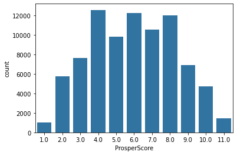

```python
sb.countplot(data= loan_sub, x= 'ProsperScore', color= base_color);
```

Observation

> Most of the borrowers were given a rating score between the range of 4 - 8 The score point of 4 is the highest score given the borrowers This figure demonstrates that the majority of the loans issued by Prosper are high risk loans.

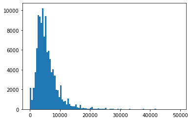

```python
# Distribution of stated monthly income
bins = np.arange(0, 50000, 500)
plt.hist(data = loan_sub, x = 'StatedMonthlyIncome', bins=bins);
```

The distribution of stated monthly income is severely right screwed, with most of stated monthly income less than 30k.

### What is the Employment Status of Borrowers?

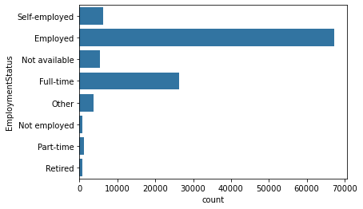

```python
sb.countplot(data= loan_sub, y= 'EmploymentStatus', color= base_color);
```

Observation

> The majority of borrowers are employed, which makes sense given how difficult it is to obtain a loan without employment.

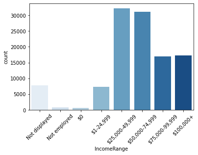

```python
# The income variable is an ordinal variable so we have to arrange it
income = ['Not displayed', 'Not employed', '$0', '$1-24,999', '$25,000-49,999',
               '$50,000-74,999', '$75,000-99,999', '$100,000+']
income_order = pd.api.types.CategoricalDtype(ordered=True, categories=income)
loan_sub['IncomeRange'] = loan_sub['IncomeRange'].astype(income_order)
#plotting with the count function
sb.countplot( data=loan_sub, x='IncomeRange', palette = 'Blues')
plt.xticks(rotation= 45);
```

Observation

> Most of the Prosper's borrowers income range falls with in the range of 25,000 - 49,999 followed by 50,000-74,999

### Were there any unusual points? Did you need to perform any transformations?

The distribution of borrowers APR looks multimodal. Most of the values are at the range of 0.05 and 0.4. There are no unusual points and no need to perform any transformations. The Original Loan Amount was right skewed with few data at the right end. After using a log transformation. We could see three high peaks at 4k, 10k and 15k

### Of the features you investigated, were there any unusual distributions? Did you perform any operations on the data to tidy, adjust, or change the form of the data? If so, why did you do this?

The distributions of stated monthly income is highly right screwed. Most stated monthly incomes are less than 30k, but some of them are incredibly high, like greater than 100k. Surprisingly, most of borrowers with greater than 100k monthly income only loan less than 5k dollars. So, the very large stated monthly income may be made up. When I looked into the EmploymentStatus variable, majority of borrowers were employed. When investigating the Income range variable, I noticed that the data is an ordinal data but it was not orderd. I had to change the form of the data by converting the data to ordinal type.

## Bivariate Exploration

### what are the relationships and correlations present between features in the data?

#### BorrowerAPR and BorrowerRate

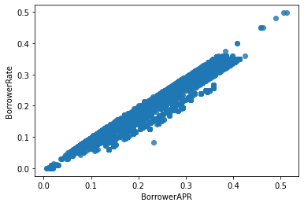

```python
sb.regplot(data= loan_sub, x= 'BorrowerAPR', y= 'BorrowerRate', fit_reg= False);
```

#### Observation

> The correlation between BorrowerAPR and BorrowerRate is 0.99, which indicates that they are strongly positive correlatively. Higher BorrowerAPR rate is strongly related to higher BorrowerRate rate

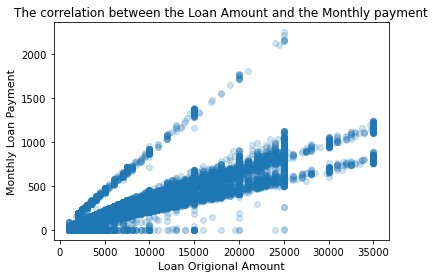

```python
sb.regplot(data = loan_sub, x = 'LoanOriginalAmount', y = 'MonthlyLoanPayment', fit_reg= False, x_jitter= 0.3, scatter_kws= {'alpha':0.2})
plt.title('The correlation between the Loan Amount and the Monthly payment')
plt.xlabel('Loan Origional Amount', fontsize=11)
plt.ylabel('Monthly Loan Payment', fontsize=11);
```

#### Observation

> This shows that there is a positive correlation between the original loan amount and the monthly payment of loan. The higher the loan amount, the higher the monthly payment of loan. The stated Monthly Income and Loan Original Amount have a 0.20 correlation

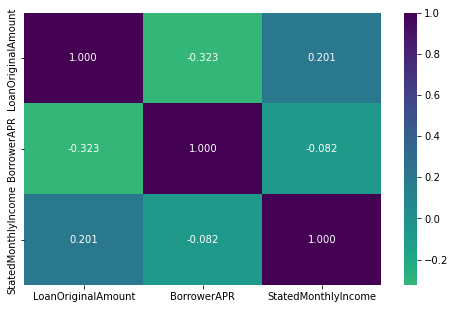

```python
num_vars = ['LoanOriginalAmount', 'BorrowerAPR', 'StatedMonthlyIncome']
cat_vars = ['Term', 'ProsperRating (Alpha)', 'EmploymentStatus']

# correlation plot
plt.figure(figsize = [8, 5])
sb.heatmap(loan_sub[num_vars].corr(), annot = True, fmt = '.3f',
           cmap = 'viridis_r', center = 0);
```

#### Observation

> The correlation coefficient of borrower APR and loan original amount is -0.323, it also shows that these two variables are negatively correlated, which agrees with our hypothesis, that is the more the loan amount, the lower the APR. The loan original amount is positively correlated with the stated monthly income, it makes sense since borrowers with more monthly income could loan more money.

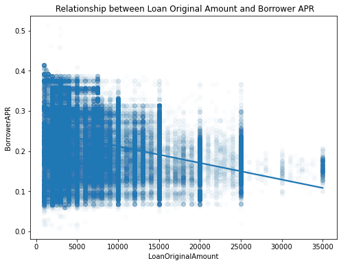

```python
plt.figure(figsize = [8, 6])
sb.regplot(data = loan_sub, x = 'LoanOriginalAmount', y = 'BorrowerAPR', scatter_kws={'alpha':1/50});
plt.title(" Relationship between Loan Original Amount and Borrower APR");
```

#### Observation

this shows the relationship between the loan amount and the APR the borrower's APR has a large distribution, but the range of APR decreases with the increase of loan amount. So the borrower's APR is negatively correlated with the total loan amount.

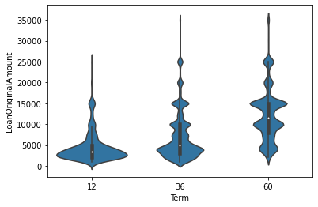

```python
color_base= sb.color_palette()[0]
sb.violinplot(data= loan_sub, x= 'Term', y= 'LoanOriginalAmount', color= color_base)
```

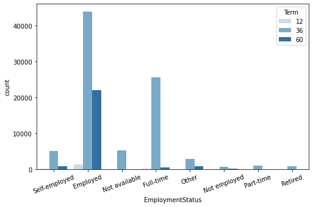

```python
# Relationship between EmploymentStatus and Term
plt.figure(figsize = [8, 5])
sb.countplot(data = loan_sub, x = 'EmploymentStatus', hue = 'Term', palette = 'Blues');
plt.xticks(rotation= 20);
```

Observation

> This shows that borrowers that were employed followed by full time collected loans for the duration of 36 months

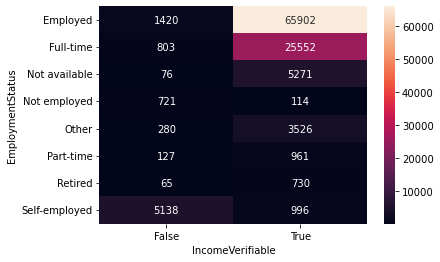

```python
# Relationship between EmploymentStatus and IncomeVerifiable
counts = loan_sub.groupby(['EmploymentStatus', 'IncomeVerifiable']).size()
counts = counts.reset_index(name='count')
counts = counts.pivot(index = 'EmploymentStatus', columns = 'IncomeVerifiable', values = 'count')
sb.heatmap(counts, annot = True, fmt = 'd');
```

This shows that income of borrowers employed is verifed

```python
#convert the ProsperRating Alpha to ordered type
rate_order = ['HR','E','D','C','B','A','AA']
ordered_var = pd.api.types.CategoricalDtype(ordered = True, categories = rate_order)
loan_sub['ProsperRating (Alpha)'] = loan_sub['ProsperRating (Alpha)'].astype(ordered_var)
```

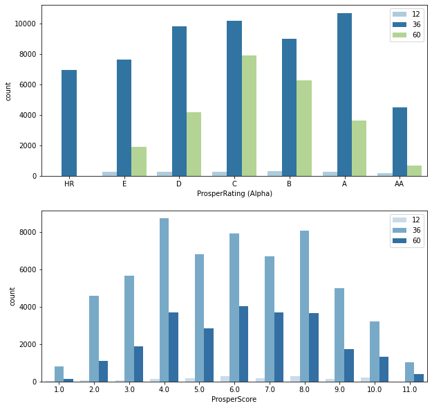

```python
# Look at relationship between Term and the ProsperRating(s) and ProsperScore
plt.figure(figsize=[10,10])


plt.subplot(2,1,1)
sb.countplot(data=loan_sub, x='ProsperRating (Alpha)', hue='Term', palette='Paired');
plt.legend(loc=1);

plt.subplot(2,1,2)
sb.countplot(data= loan_sub, x='ProsperScore', hue='Term', palette='Blues')
plt.legend(loc=1);
```

#### Observation

> There is a interaction between prosper rating and term. Proportionally, there are more 60 month loans on B and C ratings. There is only 36 months loans for HR rating borrowers while Borrowrers with a score of 4 or higher apply for loan with 36 months payment plan than loan with 12 and 36 months payment plan.

### Talk about some of the relationships you observed in this part of the investigation. How did the feature(s) of interest vary with other features in the dataset?

> When BorrowerAPR was plotted against BorrowerRate, a linear relationship was observed. BorrowerAPR and BorrowerRate had a high positive correlation. This shows that the borrower rate will increase as the BorrowerAPR rate increases. BorrowerAPR and LoanOriginalAmount have a moderately negative correlation. As a result, a larger loan will have a lower borrowerAPR rate.

### Did you observe any interesting relationships between the other features (not the main feature(s) of interest)?

> The loan original amount is positively correlated with the stated monthly income, it makes sense since borrowers with more monthly income could loan more money. It also shows that borrowers with better rating also have larger monthly income and loan amount. There is a interaction between prosper rating and term. Proportionally, there are more 60 month loans on B and C ratings. There is only 36 months loans for HR rating borrowers.

## Multivariate Exploration

The main thing I want to explore in this part of the analysis is how the categorical variable (Prosper rating and term) play into the relationship between borrower APR and loan original amount.

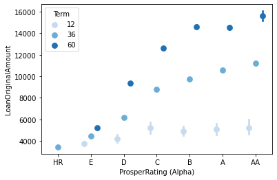

```python
sb.pointplot(data = loan_sub, x = 'ProsperRating (Alpha)', y = 'LoanOriginalAmount', hue = 'Term',
           palette = 'Blues', linestyles = '', dodge = 0.4);
```

#### Observation

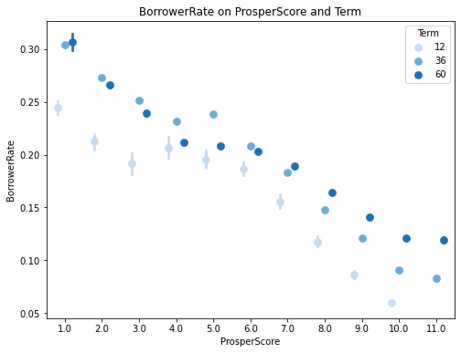

```python
fig = plt.figure(figsize = [8,6])
ax = sb.pointplot(data= loan_sub, x = 'ProsperScore', y= 'BorrowerRate', hue = 'Term', palette = 'Blues', linestyles = '', dodge = 0.4)
plt.title('BorrowerRate on ProsperScore and Term')
plt.ylabel('BorrowerRate')
plt.show();
```

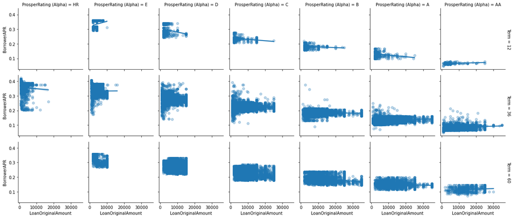

```python
d = sb.FacetGrid(data = loan_sub, col = 'ProsperRating (Alpha)', row = 'Term', size = 2.5, margin_titles = True)
d.map(sb.regplot, 'LoanOriginalAmount', 'BorrowerAPR', x_jitter=0.04, scatter_kws={'alpha':0.3});
```

## Conclusions

The most frequent loan amount collected by prosper borrowers is 4k followed by 15k and 10k

The most frequent terms of loan is 36 months (medium-term), followed by 60 months (long-term) and 12 month (short term)

Higher BorrowerAPR rate is strongly related to higher BorrowerRate rate

The correlation between BorrowerAPR and loan amount is moderately negative correlection. The higher the loan amount fee, the Lower the BorrowerAPR and the lower the loan amount fee. the higher the BorrowerAPR